# Statistical Inference Part1

Armin Wallrab

Mai 2015

# Statistical Inference

## Part 1: Simulation

In this project I will investigate the exponential distribution in R and compare it with the Central Limit Theorem. The exponential distribution can be simulated in R with rexp(n, lambda) where lambda is the rate parameter. The mean of exponential distribution is 1/lambda and the standard deviation is also 1/lambda. I set lambda = 0.2 for all of the simulations. I’ll investigate the distribution of averages of 40 exponentials with a thousand simulations.

```r
library(ggplot2)
set.seed(123)
lambda <- 0.2
n <- 40
runs <- 1000
sim <- matrix(rexp(runs*n, rate=lambda), runs)
sim_means <- rowMeans(sim)
```

### 1. Show the sample mean and compare it to the theoretical mean of the distribution

```r
# mean of the simulation and the distribution
c(mean(sim_means), 1/lambda)
```

```
## [1] 5.011911 5.000000
```

The simulated and theoretical mean values are very close, as expected by the Central Limit Theorem. The distributions are centered around the same values.

### 2. Show how variable the sample is (via variance) and compare it to the theoretical variance of the distribution

```r
# compare the variances
sim_var <- var(sim_means)
the_var <- 1/lambda**2/n
c(sim_var, the_var)
```

```
## [1] 0.6088292 0.6250000
```

The simulated and theoretical variances are also very close.

### 3. Show that the distribution is approximately normal

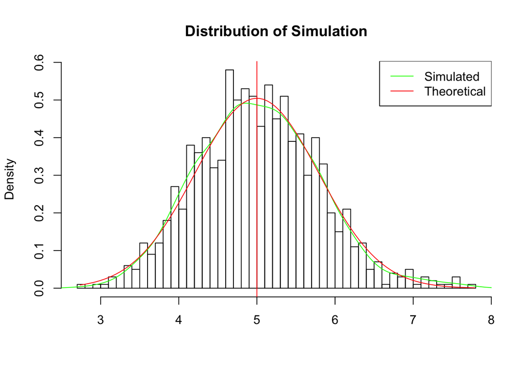

```r
library(ggplot2)
hist(sim_means, breaks=40, probability=TRUE, main="Distribution of Simulation", xlab="")
lines(density(sim_means), col="green")
abline(v=1/lambda, col="red")
xfit <- seq(min(sim_means), max(sim_means), length=100)
yfit <- dnorm(xfit, mean=1/lambda, sd=(1/lambda/sqrt(n)))
lines(xfit, yfit, pch=22, col="red")
# add a legend
legend('topright', c("Simulated", "Theoretical"), col=c("green", "red"), lty=c(1,1))
```

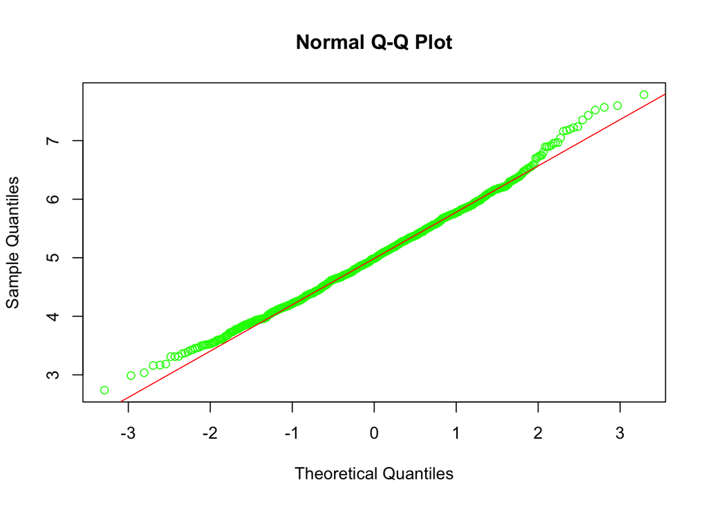

```r
qqnorm(sim_means, col="green")
qqline(sim_means, col="red")
```

Last but not least, to verify I’ll also try to match the confidence intervals which are calculated below:

```r
sim_ci <- mean(sim_means) + c(-1,1)*1.96*sd(sim_means)/sqrt(n)
the_ci <- 1/lambda + c(-1,1)*1.96*sqrt(the_var)/sqrt(n);
c(sim_ci, the_ci)
```

```
## [1] 4.770102 5.253721 4.755000 5.245000
```

This shows that the distribution is normal as expected with the CLT.